# plot_clustermap

```python
# this is jut to view the wide window in jupyter
from IPython.core.display import display, HTML
display(HTML("<style>.container { width:100% !important; }</style>"))
```

```python
# load the libraries needed
import os
import pandas as pd
import numpy as np
import matplotlib.pyplot as plt
import seaborn as sns
```

## Define functions for plotting

```python
def extract_region(df, chromosome, down_region, up_region, function=None):
    region_df = df[(df['end'] >= down_region) & (df['start'] <= up_region) &
                   (df['seqname'].str.contains(chromosome))]
    header = region_df[['seqname','end']]
    values = region_df.iloc[:, 3:] # take only columns after "end" column
    if function == None:
        return pd.concat([header, values], axis=1)
    else:
        values_func = function(values).replace(-np.inf, 0)
        return pd.concat([header, values_func], axis=1)
# consider split the above function in two and put the scaled function as below
def scale_data(df,function):
    header = df[['seqname','end']]
    values = df.iloc[:, 3:] # take only columns after "end" column
    values_func = function(values).replace(-np.inf, 0)
    return pd.concat([header, values_func], axis=1)

def transpose_df(df):
    df_t = df.set_index(['seqname', 'end']).T
    return df_t

def plot_culstermap_col(df, fig_size=(25,300)):
    colors = ["orange", "lightgray"]
    cmap = LinearSegmentedColormap.from_list('Custom', colors, len(colors))

    sns.set(rc={'axes.facecolor':'white', 'figure.facecolor':'white'})
    cluster = sns.clustermap(df,
                            cmap=cmap,
                            cbar=False,
                            vmin=0,
                            col_cluster=False,
                            # row_cluster = False, # avoid cluster rows
                            figsize=fig_size,
                            cbar_pos=(0, .4, .005, .4),
                            dendrogram_ratio=(.0001, .005))
    plt.setp(cluster.ax_heatmap.xaxis.get_majorticklabels(), rotation=90, fontsize=15)
    plt.setp(cluster.ax_heatmap.yaxis.get_majorticklabels(), fontsize=15)
    return cluster

def drop_columns_rex(df, string):
    droped_df = df.set_index(['seqname', 'start', 'end']).drop(df.filter(regex=string).columns, axis=1)
    return droped_df.reset_index()

def drop_columns_list(df,sample_list):
    droped_df = df.set_index(['seqname', 'start', 'end']).drop(my_list, axis=1)
    return droped_df.reset_index()

def select_genotypes(df, sample_list):
    filter_df = df.set_index(['seqname', 'start', 'end']).filter(items=sample_list, axis=1)
    return filter_df.reset_index()

def chr_length(df, chromosome):
    len_df = pd.read_csv(df, delimiter='\t', header=None)
    return len_df[len_df[0].str.contains(f'{chromosome}')][1].values[0]
```

```python
#Path to the files
# data_path = '/Volumes/quirozj/09_watseq/03_haplotypes/ibspy_analysis/ibspy_combined/variations/all_assemblies_ibspy_variaitons'
data_path = '/Users/quirozc/Documents/PhD_2020/16_watseq/0_IBSpy_data'
chr_path = '/Users/quirozc/Documents/PhD_2020/16_watseq/00_genome_sizes/'
```

## Define arguments

- Here you can define arguments to plot. In the example below, I'm usig the file that has 50,000 bp windows (we have other files with other windows sizes).
- the "function" is a data transformation to the sqrt to get better vizualization.
- chromosome to filter. This because these files contain all the cromosomes
- and then the region to plot (down_region, up_region)

```python
# Define arguments chinese
window = 50000
function = np.sqrt
reference = 'lancer'
```

```python
# # this is juts to list the files in my current directory
# import os
# files = os.listdir('./01_data/')
# files
```

## Read the file

#### NOTE: this file has all the "query" samples merged in a single file by reference

```python
in_file = pd.read_csv(f'{data_path}/{reference}_combined_queries_{window}w.tsv.gz', delimiter='\t')
in_file
```

|  | seqname | start | end | arina-10x_nuq | arina-pg | cadenza-10.4x_nuq | cadenza-15x_nuq | chinese-10x_nuq | chinese-pg | claire-10x_nuq | ... | WATDE0967 | WATDE0228 | WATDE0750 | WATDE0627 | WATDE0158 | WATDE0185 | WATDE0164 | WATDE0015 | WATDE0180 | WATDE0700 |
| --- | --- | --- | --- | --- | --- | --- | --- | --- | --- | --- | --- | --- | --- | --- | --- | --- | --- | --- | --- | --- | --- |
| 0 | chr1A_Whlan | 1 | 50000 | 421 | 540 | 34 | 27 | 13 | 20 | 65 | ... | 26 | 37 | 449 | 28 | 28 | 26 | 30 | 34 | 440 | 458 |
| 1 | chr1A_Whlan | 50001 | 100000 | 487 | 556 | 36 | 25 | 16 | 23 | 36 | ... | 26 | 32 | 490 | 36 | 37 | 30 | 28 | 31 | 494 | 505 |
| 2 | chr1A_Whlan | 100001 | 150000 | 518 | 571 | 40 | 25 | 17 | 26 | 104 | ... | 27 | 39 | 522 | 36 | 31 | 36 | 28 | 34 | 513 | 505 |
| 3 | chr1A_Whlan | 150001 | 200000 | 498 | 546 | 40 | 28 | 14 | 22 | 34 | ... | 30 | 38 | 523 | 35 | 36 | 162 | 30 | 42 | 507 | 521 |
| 4 | chr1A_Whlan | 200001 | 250000 | 449 | 533 | 44 | 32 | 13 | 24 | 27 | ... | 27 | 44 | 475 | 21 | 38 | 30 | 25 | 23 | 482 | 472 |
| ... | ... | ... | ... | ... | ... | ... | ... | ... | ... | ... | ... | ... | ... | ... | ... | ... | ... | ... | ... | ... | ... |
| 285871 | chrUn_Whlan | 421400001 | 421450000 | 80 | 89 | 104 | 100 | 80 | 120 | 81 | ... | 93 | 99 | 144 | 89 | 85 | 83 | 72 | 86 | 99 | 86 |
| 285872 | chrUn_Whlan | 421450001 | 421500000 | 131 | 131 | 110 | 108 | 131 | 136 | 99 | ... | 121 | 122 | 149 | 155 | 155 | 108 | 120 | 94 | 78 | 127 |
| 285873 | chrUn_Whlan | 421500001 | 421550000 | 76 | 93 | 115 | 107 | 78 | 111 | 81 | ... | 107 | 129 | 83 | 140 | 82 | 129 | 118 | 95 | 94 | 99 |
| 285874 | chrUn_Whlan | 421550001 | 421600000 | 94 | 106 | 77 | 69 | 97 | 132 | 88 | ... | 69 | 126 | 108 | 153 | 102 | 71 | 107 | 141 | 97 | 110 |
| 285875 | chrUn_Whlan | 421600001 | 421650000 | 106 | 139 | 77 | 75 | 59 | 91 | 101 | ... | 127 | 93 | 113 | 151 | 87 | 81 | 79 | 105 | 103 | 105 |

285876 rows × 1422 columns

## Filter samples

- This filter can be ommited of you want to keep all the samples. In the example below I'm filtering the Aegilops tauschii accesions (prefix 'BW_')

```python
droped_file = drop_columns_rex(in_file,'BW_')
# droped_file = in_file
droped_file
```

|  | seqname | start | end | arina-10x_nuq | arina-pg | cadenza-10.4x_nuq | cadenza-15x_nuq | chinese-10x_nuq | chinese-pg | claire-10x_nuq | ... | WATDE0967 | WATDE0228 | WATDE0750 | WATDE0627 | WATDE0158 | WATDE0185 | WATDE0164 | WATDE0015 | WATDE0180 | WATDE0700 |
| --- | --- | --- | --- | --- | --- | --- | --- | --- | --- | --- | --- | --- | --- | --- | --- | --- | --- | --- | --- | --- | --- |
| 0 | chr1A_Whlan | 1 | 50000 | 421 | 540 | 34 | 27 | 13 | 20 | 65 | ... | 26 | 37 | 449 | 28 | 28 | 26 | 30 | 34 | 440 | 458 |
| 1 | chr1A_Whlan | 50001 | 100000 | 487 | 556 | 36 | 25 | 16 | 23 | 36 | ... | 26 | 32 | 490 | 36 | 37 | 30 | 28 | 31 | 494 | 505 |
| 2 | chr1A_Whlan | 100001 | 150000 | 518 | 571 | 40 | 25 | 17 | 26 | 104 | ... | 27 | 39 | 522 | 36 | 31 | 36 | 28 | 34 | 513 | 505 |
| 3 | chr1A_Whlan | 150001 | 200000 | 498 | 546 | 40 | 28 | 14 | 22 | 34 | ... | 30 | 38 | 523 | 35 | 36 | 162 | 30 | 42 | 507 | 521 |
| 4 | chr1A_Whlan | 200001 | 250000 | 449 | 533 | 44 | 32 | 13 | 24 | 27 | ... | 27 | 44 | 475 | 21 | 38 | 30 | 25 | 23 | 482 | 472 |
| ... | ... | ... | ... | ... | ... | ... | ... | ... | ... | ... | ... | ... | ... | ... | ... | ... | ... | ... | ... | ... | ... |
| 285871 | chrUn_Whlan | 421400001 | 421450000 | 80 | 89 | 104 | 100 | 80 | 120 | 81 | ... | 93 | 99 | 144 | 89 | 85 | 83 | 72 | 86 | 99 | 86 |
| 285872 | chrUn_Whlan | 421450001 | 421500000 | 131 | 131 | 110 | 108 | 131 | 136 | 99 | ... | 121 | 122 | 149 | 155 | 155 | 108 | 120 | 94 | 78 | 127 |
| 285873 | chrUn_Whlan | 421500001 | 421550000 | 76 | 93 | 115 | 107 | 78 | 111 | 81 | ... | 107 | 129 | 83 | 140 | 82 | 129 | 118 | 95 | 94 | 99 |
| 285874 | chrUn_Whlan | 421550001 | 421600000 | 94 | 106 | 77 | 69 | 97 | 132 | 88 | ... | 69 | 126 | 108 | 153 | 102 | 71 | 107 | 141 | 97 | 110 |
| 285875 | chrUn_Whlan | 421600001 | 421650000 | 106 | 139 | 77 | 75 | 59 | 91 | 101 | ... | 127 | 93 | 113 | 151 | 87 | 81 | 79 | 105 | 103 | 105 |

285876 rows × 1158 columns

```python
# droped_file.iloc[:,3:]
```

```python
%%time
def transform_df(df, value):
    df_t = df.set_index(['seqname','start', 'end'])
    df_1 = df_t.where(df_t > value, 0)
    df_out = df_1.where(df_1 < value, 1).reset_index()
    return df_out

# x_df = transform_df(droped_file, 130)
# x_df
```

```
CPU times: user 3 µs, sys: 1 µs, total: 4 µs
Wall time: 5.96 µs
```

## Extract the region we want to plot. In this case the whole chromosome

- With this filter you can plot any region you want, just put chromosome & the coordenates (down_region, up_region in the example below)
- The function parameter transform the original data to its sqrt (this is jut to have a better vuzualization)

```python
# chromosome='chr2B'
# chr_len = chr_path+f'chr_sizes_{reference}.genome.txt'
# down_region = 0
# # up_region = chr_length(chr_len, chromosome)
# up_region = 150000000

# region = extract_region(x_df, chromosome, down_region, up_region)
# region
```

## Transpose the data to use samples as a rows (Y, axis) and chromosome positions as X axis

- This is jut to plot the genotypes in the Y axis, and the chromosome coordentaes in the X axis

```python
# %%time
# region_t = transpose_df(region)
# region_t
```

## Create the clustermap

- depending of the number of samples you want to include, you can change the fig_size parameter to have better vusualization.
- WARNING: if you include all the samples and the whole chromosome this may take too much memory, depending of your computer power.

```python
# fig_size=(35,300)
# plot_culstermap_col(region_t, fig_size).fig.suptitle(f'reference: {reference}_{chromosome}', fontsize=20, weight="bold", x=0.5, y=0.997) # x and y are the position of text title
# plt.savefig(f'{chromosome}_{reference}_clustermap_all_samples.pdf', dpi=70, bbox_inches='tight')
```

### Include few samples

```python
# hap_path='/Users/quirozc/Documents/PhD_2020/16_watseq/22_paul/06_hap_names/'
my_list = pd.read_csv('timopheevii_genotypes.tsv')['genotype'].tolist()
filtered_file = select_genotypes(in_file, my_list)
filtered_file
```

|  | seqname | start | end | timopheevii10558_nuq.jf | lancer-10x_nuq | mattis-pg | Diablo | Stava | Riband | malacca | Cordiale | Crusoe | Grafton | Moisson |
| --- | --- | --- | --- | --- | --- | --- | --- | --- | --- | --- | --- | --- | --- | --- |
| 0 | chr1A_Whlan | 1 | 50000 | 81 | 0 | 418 | 29 | 24 | 437 | 59 | 37 | 55 | 24 | 423 |
| 1 | chr1A_Whlan | 50001 | 100000 | 32 | 2 | 489 | 26 | 25 | 493 | 32 | 38 | 41 | 27 | 478 |
| 2 | chr1A_Whlan | 100001 | 150000 | 68 | 0 | 510 | 33 | 27 | 511 | 106 | 50 | 42 | 31 | 473 |
| 3 | chr1A_Whlan | 150001 | 200000 | 40 | 0 | 500 | 33 | 26 | 517 | 38 | 47 | 40 | 26 | 507 |
| 4 | chr1A_Whlan | 200001 | 250000 | 42 | 0 | 454 | 38 | 22 | 457 | 31 | 32 | 39 | 23 | 474 |
| ... | ... | ... | ... | ... | ... | ... | ... | ... | ... | ... | ... | ... | ... | ... |
| 285871 | chrUn_Whlan | 421400001 | 421450000 | 413 | 0 | 143 | 99 | 97 | 127 | 97 | 100 | 94 | 75 | 120 |
| 285872 | chrUn_Whlan | 421450001 | 421500000 | 473 | 9 | 86 | 149 | 132 | 88 | 108 | 85 | 119 | 106 | 115 |
| 285873 | chrUn_Whlan | 421500001 | 421550000 | 480 | 2 | 88 | 144 | 123 | 95 | 117 | 117 | 134 | 89 | 151 |
| 285874 | chrUn_Whlan | 421550001 | 421600000 | 440 | 2 | 121 | 130 | 110 | 118 | 101 | 131 | 70 | 68 | 88 |
| 285875 | chrUn_Whlan | 421600001 | 421650000 | 350 | 2 | 110 | 134 | 121 | 120 | 138 | 129 | 98 | 97 | 92 |

285876 rows × 14 columns

## Clustermap some samples

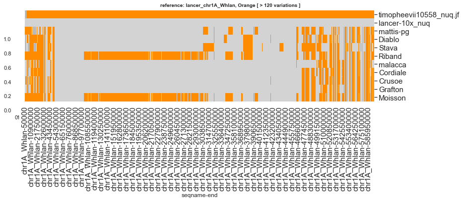

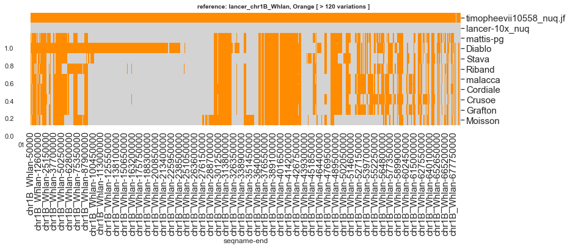

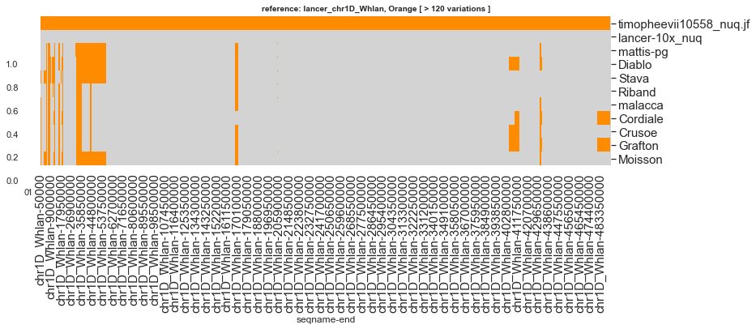

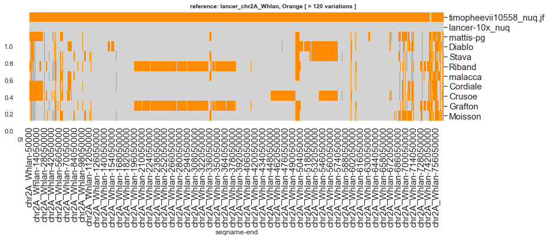

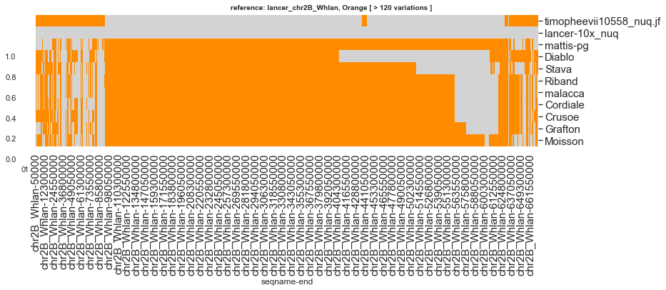

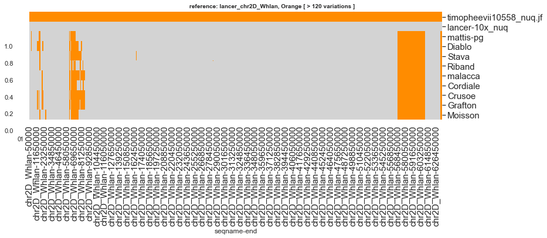

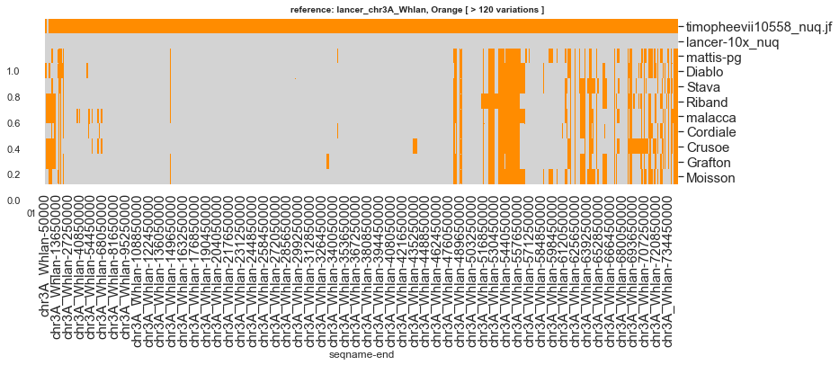

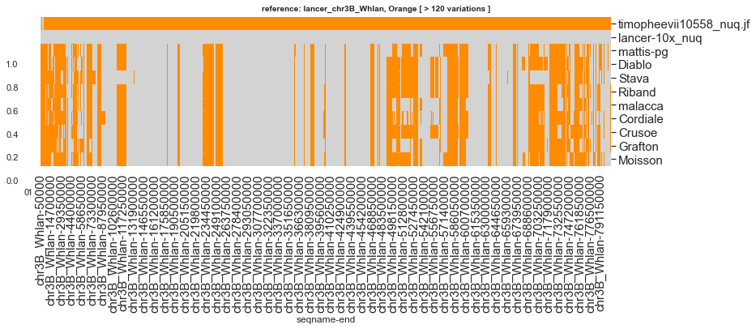

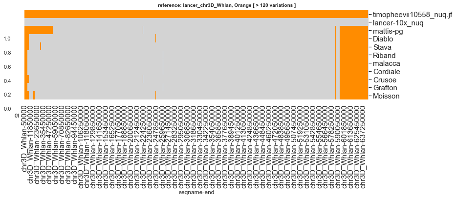

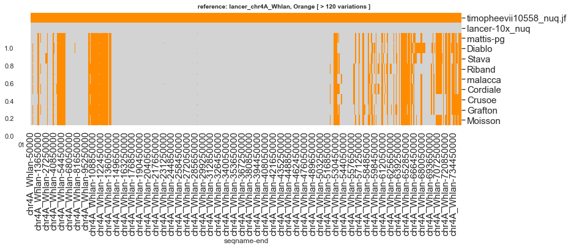

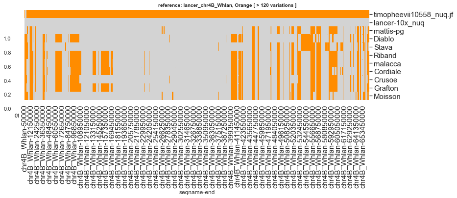

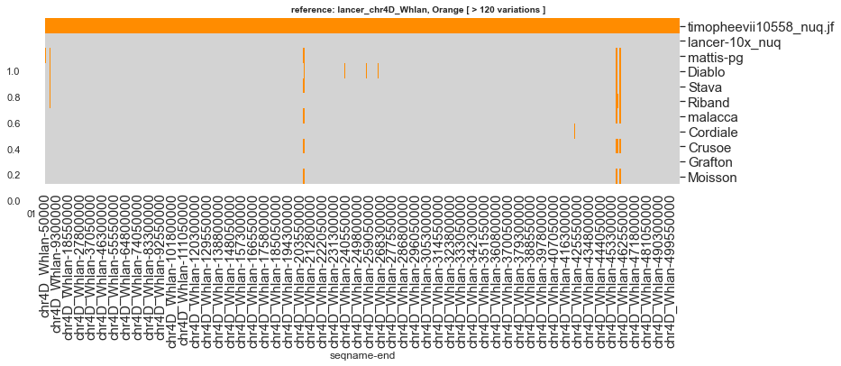

[10 more figures not shown]

```python
fig_size=(12,5)
down_region = 0
up_region = 805000000
# chromosome ='chr2D'
filter_v = 120
# x_df = transform_df(filtered_file, 128)
# x_df
chromosomes = filtered_file['seqname'].unique().tolist()
for chromosome in chromosomes:
    df_t = transpose_df(extract_region(transform_df(filtered_file, filter_v), chromosome, down_region, up_region))
    plot_culstermap_col(df_t, fig_size).fig.suptitle(f'reference: {reference}_{chromosome}, Orange [ > {filter_v} variations ]', fontsize=10, weight="bold", x=0.5, y=1)
#     plt.savefig(f'{chromosome}_{reference}_clustermap.jpg', dpi=70, bbox_inches='tight')
```

```python
from matplotlib.colors import LinearSegmentedColormap
def plot_culstermap_col(df, fig_size=(25,300)):
    colors = ["lightgray", "darkorange"]
    cmap = LinearSegmentedColormap.from_list('Custom', colors, len(colors))

    sns.set(rc={'axes.facecolor':'white', 'figure.facecolor':'white'})
    cluster = sns.clustermap(df,
                            cmap=cmap,
#                             linewidths=10,
#                             tree_kws=dict(linewidths=1.5, colors=(0.2, 0.2, 0.4)),
                            cbar=False,
                            vmin=0,
                            col_cluster=False,
                            row_cluster = False, # avoid cluster rows
                            figsize=fig_size,
                            cbar_pos=(0, .4, .005, .4),
                            dendrogram_ratio=(.0001, .005))
    for a in cluster.ax_row_dendrogram.collections:
        a.set_linewidth(10)

    plt.setp(cluster.ax_heatmap.xaxis.get_majorticklabels(), rotation=90, fontsize=15)
    plt.setp(cluster.ax_heatmap.yaxis.get_majorticklabels(), fontsize=15)
    return cluster
```